# Seaweed experiment 16s data

Christian Diener cdiener@systemsbiology.org

# Effects of diet

## Data preparation

We will start by reading our data and required libraries.

```r
library(mbtools)

ps <- readRDS("data/seaweed_exp.rds")
fig_data <- readRDS("data/fig_data.rds")
```

We sill start by building up a dataframe that combines phyla abundances and sample metadata.

```r
phyla <- taxa_count(ps, "Phylum")

sdata <- as.data.table(as(sample_data(ps), "data.frame"))
phyla <- phyla[sdata, on = c(sample = "CategoricalID")]
fig_data[["Fig. 2D"]] <- phyla
head(phyla)
```

| sample | taxa | reads | Sample | Group | Subject | Month | MonthCat | Date | DateCat | DaysElapsed | DaysElapsedCat | Timepoint | TimepointCat | ExperimentPhase | Weight | WeightCat | WeightRounded | WeightRoundedCat | Response | Days | seaweed | Ct |
| --- | --- | --- | --- | --- | --- | --- | --- | --- | --- | --- | --- | --- | --- | --- | --- | --- | --- | --- | --- | --- | --- | --- |
| a1.d20 | Actinobacteria | 49 | sample-2 | A | A1 | 5 | 5 | 29 | 29 | 20 | 20 | 2 | before | Diet | 18.8 | 18.8 | 19 | 19 | responder | 20 | FALSE | 11.38 |
| a1.d20 | Bacteroidetes | 23509 | sample-2 | A | A1 | 5 | 5 | 29 | 29 | 20 | 20 | 2 | before | Diet | 18.8 | 18.8 | 19 | 19 | responder | 20 | FALSE | 11.38 |
| a1.d20 | Cyanobacteria | 4 | sample-2 | A | A1 | 5 | 5 | 29 | 29 | 20 | 20 | 2 | before | Diet | 18.8 | 18.8 | 19 | 19 | responder | 20 | FALSE | 11.38 |
| a1.d20 | Firmicutes | 16392 | sample-2 | A | A1 | 5 | 5 | 29 | 29 | 20 | 20 | 2 | before | Diet | 18.8 | 18.8 | 19 | 19 | responder | 20 | FALSE | 11.38 |
| a1.d20 | Proteobacteria | 574 | sample-2 | A | A1 | 5 | 5 | 29 | 29 | 20 | 20 | 2 | before | Diet | 18.8 | 18.8 | 19 | 19 | responder | 20 | FALSE | 11.38 |
| a1.d20 | Tenericutes | 1479 | sample-2 | A | A1 | 5 | 5 | 29 | 29 | 20 | 20 | 2 | before | Diet | 18.8 | 18.8 | 19 | 19 | responder | 20 | FALSE | 11.38 |

# Phyla abundances

## By exposure

First we have to assemble the relative abundances for controls.

```r
treated <- phyla[DaysElapsed == 31]
treated[, relative := reads / sum(reads, na.rm=T),
        by = c("seaweed", "Response")]

high_taxa <- phyla[DaysElapsed == 31,
                   .(taxa=taxa, rel=reads / sum(reads)),
                   by = "sample"][rel > 1e-3, unique(taxa)]
```

Let us visualize rough differences.

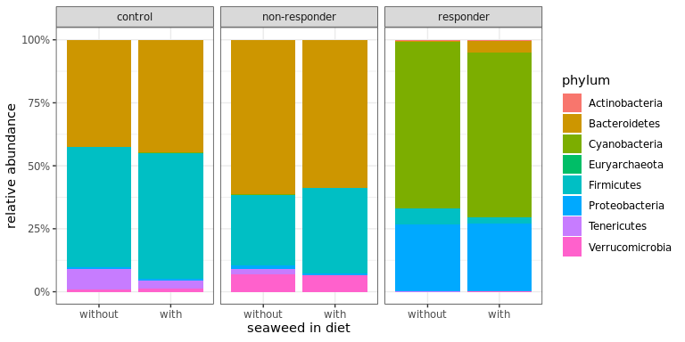

```r
pl <- ggplot(treated[taxa %in% high_taxa],
             aes(x = factor(seaweed), y = relative, fill = taxa)) +
  geom_bar(stat = "identity") + scale_y_continuous(labels = scales::percent) +
  facet_wrap(~ Response) + theme_bw() +
  scale_x_discrete(labels = c("without", "with")) +
  labs(x = "seaweed in diet", y = "relative abundance", fill = "phylum")
ggsave("figures/treatment_seaweed.png", height = 4, width = 8, dpi = 300)
pl
```

Sample sizes:

```r
treated[, uniqueN(sample), by = c("Response", "seaweed")]
```

| Response | seaweed | V1 |
| --- | --- | --- |
| responder | FALSE | 6 |
| non-responder | FALSE | 2 |
| control | FALSE | 6 |
| responder | TRUE | 6 |
| non-responder | TRUE | 2 |
| control | TRUE | 6 |

We can see that most of the Cyanobacteria and Proteobacteria are actually Chloroplasts and Mitochondria:

```r
non_responders <- subset_samples(ps, Response == "responder")
cyano_proteo <- subset_taxa(non_responders,
                            Phylum %in% c("Cyanobacteria", "Proteobacteria"))
class <- taxa_count(cyano_proteo, "Order")[order(-reads), sum(reads), by = taxa]
fam <- taxa_count(cyano_proteo, "Family")[order(-reads), sum(reads), by = taxa]
print(class[, .(taxa, relative = V1 / sum(V1))])
```

| taxa | relative |
| --- | --- |
| Chloroplast | 6.709071e-01 |
| Rickettsiales | 2.661984e-01 |
| Betaproteobacteriales | 5.509717e-02 |
| Acetobacterales | 1.169820e-03 |
| Enterobacteriales | 1.966009e-03 |
| Sphingomonadales | 6.849894e-04 |
| Xanthomonadales | 1.192059e-03 |
| Rhizobiales | 1.534554e-03 |
| Pseudomonadales | 5.026221e-04 |
| Caulobacterales | 2.446391e-04 |

[output cut: 9 more lines]

```r
print(fam[, .(taxa, relative = V1 / sum(V1))])
```

| taxa | relative |
| --- | --- |
| Mitochondria | 8.092353e-01 |
| Burkholderiaceae | 1.674937e-01 |
| Acetobacteraceae | 3.556217e-03 |
| Enterobacteriaceae | 5.976607e-03 |
| Sphingomonadaceae | 2.082347e-03 |
| Xanthomonadaceae | 3.569738e-03 |
| Rhizobiaceae | 2.893652e-03 |
| Moraxellaceae | 6.760868e-04 |
| Beijerinckiaceae | 7.436955e-04 |
| Xanthobacteraceae | 7.436955e-04 |

[output cut: 12 more lines]

## Summarized

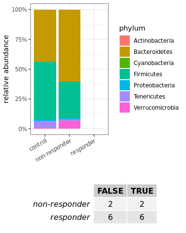

```r
library(gridExtra)

treated <- phyla[DaysElapsed == 31]
treated[, relative := reads / sum(reads), by = "Response"]

bars <- ggplot(treated[taxa %in% high_taxa],
               aes(x = Response, y = relative, fill = taxa)) +
  geom_bar(stat = "identity") + scale_y_continuous(labels = scales::percent) +
  theme_bw() +
  theme(axis.text.x = element_text(angle = 30, hjust = 1, vjust = 1)) +
  labs(x = "", y = "relative abundance", fill = "phylum")
after_exposure <- sdata[DaysElapsed == 31]
resp_counts <- after_exposure[, table(Response, seaweed)][2:3, ]
tbl <- tableGrob(resp_counts)
pl <- grid.arrange(bars, tbl, nrow = 2, as.table = T, heights = c(3, 1))
```

```r
ggsave("figures/summary_seaweed.svg", plot = pl, height = 6, width = 4)
pl
```

| z | cells | name | grob |
| --- | --- | --- | --- |
| 1 | (1-1,1-1) | arrange | gtable[layout] |
| 2 | (2-2,1-1) | arrange | gtable[rowhead-fg] |

And the corresponding Fisher test:

```r
fisher.test(resp_counts) %>% print
```

```
    Fisher's Exact Test for Count Data

data:  resp_counts
p-value = 1
alternative hypothesis: true odds ratio is not equal to 1
95 percent confidence interval:
  0.05471942 18.27504869
sample estimates:
odds ratio
         1
```

# Beta diversity

We are interested in the beta diversity between samples after treatment, so we will start by selecting a subset of those and calculating the ordination. We will look at the sequencing depth to get a decent depth for rarefaction.

```r
treat <- subset_samples(ps, DaysElapsed >= 20)
sample_sums(treat)
```

```
a1.d20 a1.d31 a1.d35 a1.d41 a2.d20 a2.d31 a2.d35 a2.d41 a3.d20 a3.d31 a3.d35 a3.d41 a4.d31 a5.d31 a6.d31 a7.d31
 42173  43125  34708  33242     94  30130  30629  33344  35593  29277  33635  37576  32093  45699   6324   8838
a8.d31 b1.d20 b1.d31 b1.d35 b1.d41 b2.d20 b2.d31 b2.d35 b2.d41 b3.d20 b3.d31 b3.d35 b3.d41 b4.d31 b5.d31 b6.d31
 39921  42019  35997  38337  32893  37452  31261  39553  34338  35391  36628  36338  28018  36487  32167  33226
c1.d20 c1.d31 c1.d35 c1.d41 c2.d20 c2.d31 c2.d35 c2.d41 c3.d20 c3.d31 c3.d35 c3.d41 c4.d31 c5.d31 c6.d31 c7.d31
 40802      0  30785  34016  35483  27306  37623  31228  36586  35146  39390  31842  24785  14968   6245  38758
c8.d31 d1.d20 d1.d31 d1.d35 d1.d41 d2.d20 d2.d31 d2.d35 d2.d41 d3.d20 d3.d31 d3.d35 d3.d41 d4.d31 d5.d31 d6.d31
  8481  34227  38665     51  39907  40479  37243  39648  36377  34158  41022  37010  33380  40222    649  43758
```

```r
ord <- rarefy_even_depth(treat, 5000) %>%
       ordinate(., method = "PCoA", distance = "bray")
```

```
You set `rngseed` to FALSE. Make sure you've set & recorded
 the random seed of your session for reproducibility.
See `?set.seed`

...
4 samples removedbecause they contained fewer reads than `sample.size`.
Up to first five removed samples are:

a2.d20c1.d31d1.d35d5.d31
...
538OTUs were removed because they are no longer
present in any sample after random subsampling

...
```

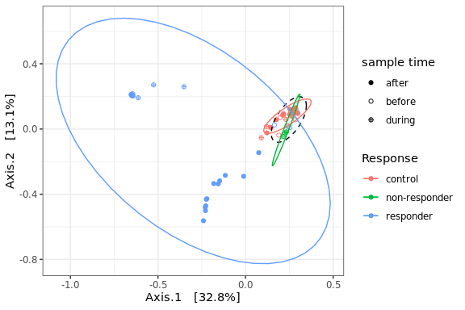

```r
data <- plot_ordination(treat, ord, color = "Response",
                      shape = "TimepointCat", justDF = T)
pl <- plot_ordination(treat, ord, color = "Response",
                      shape = "TimepointCat") +
      stat_ellipse(data = data[data$TimepointCat == "before", ],
                   aes(group = TimepointCat), lty = "dashed") +
      stat_ellipse(aes(group = Response), type = "t") +
      scale_shape_manual(values = c(before = 1, during = 10, after = 19)) +
      labs(shape = "sample time") + theme_bw()
fig_data[["Fig. 2E"]] <- data
ggsave("figures/treatment_pcoa_seaweed.svg", width = 6, height = 4)
pl
```

And the corresponding PERMANOVA for all samples:

```r
library(vegan)

allresp <- rarefy_even_depth(treat, 5000)
```

```
You set `rngseed` to FALSE. Make sure you've set & recorded
 the random seed of your session for reproducibility.
See `?set.seed`

...
4 samples removedbecause they contained fewer reads than `sample.size`.
Up to first five removed samples are:

a2.d20c1.d31d1.d35d5.d31
...
554OTUs were removed because they are no longer
present in any sample after random subsampling

...
```

```r
counts <- as.matrix(taxa_count(allresp, NA))
sda <- as(sample_data(allresp), "data.frame")
permanova <- adonis(counts ~ seaweed*Response, data = sda)
permanova
```

```
Call:
adonis(formula = counts ~ seaweed * Response, data = sda)

Permutation: free
Number of permutations: 999

Terms added sequentially (first to last)

                 Df SumsOfSqs MeanSqs F.Model      R2 Pr(>F)
seaweed           1    0.2832 0.28317  1.0047 0.01393  0.374
Response          2    4.3664 2.18320  7.7463 0.21473  0.001 ***
seaweed:Response  2    0.4655 0.23277  0.8259 0.02289  0.633
Residuals        54   15.2193 0.28184         0.74845
Total            59   20.3344                 1.00000
---
Signif. codes:  0 ‘***’ 0.001 ‘**’ 0.01 ‘*’ 0.05 ‘.’ 0.1 ‘ ’ 1
```

…and only controls vs. non-responders:

```r
library(vegan)

noresp <- subset_samples(treat, TimepointCat == "before") %>%
          rarefy_even_depth(., 5000)
```

```
You set `rngseed` to FALSE. Make sure you've set & recorded
 the random seed of your session for reproducibility.
See `?set.seed`

...
1 samples removedbecause they contained fewer reads than `sample.size`.
Up to first five removed samples are:

a2.d20
...
1644OTUs were removed because they are no longer
present in any sample after random subsampling

...
```

```r
counts <- as.matrix(taxa_count(noresp, NA))
sda <- as(sample_data(noresp), "data.frame")
permanova <- adonis(counts ~ seaweed*Response, data = sda)
permanova
```

```
Call:
adonis(formula = counts ~ seaweed * Response, data = sda)

Permutation: free
Number of permutations: 999

Terms added sequentially (first to last)

                 Df SumsOfSqs MeanSqs F.Model      R2 Pr(>F)
seaweed           1   0.51924 0.51924  3.7360 0.30640  0.007 **
Response          1   0.10014 0.10014  0.7205 0.05909  0.650
seaweed:Response  1   0.10239 0.10239  0.7367 0.06042  0.634
Residuals         7   0.97289 0.13898         0.57409
Total            10   1.69466                 1.00000
---
Signif. codes:  0 ‘***’ 0.001 ‘**’ 0.01 ‘*’ 0.05 ‘.’ 0.1 ‘ ’ 1
```

So seaweed is not related to the response type.

## Differential tests

We will use corn cob to test for differences in abundance between responders and non-responders for each timepoint category.

We will use a few helpers to summarize the tables and corncob output.

```r
source("helpers.R")
```

### For phyla

```r
library(corncob)

phylum <- subset_samples(ps, TimepointCat == "before") %>% collapse("Phylum")

tests <- differentialTest(
  formula = ~ Response,
  phi.formula = ~ 1,
  formula_null = ~ 1,
  phi.formula_null = ~ 1,
  data = phylum,
  test = "LRT",
  boot = F
) %>% results_table()
```

```r
fwrite(tests[order(padj)], "data/tests_seaweed_before_phyla.csv")
tests[order(padj)]
```

| taxon | pvalue | padj | coef | se | variable |
| --- | --- | --- | --- | --- | --- |
| Bacteroidetes | 0.8502958 | 0.934471 | -0.06487947 | 0.3435062 | mu.Responseresponder |
| Firmicutes | 0.9344710 | 0.934471 | 0.02751936 | 0.3345851 | mu.Responseresponder |
| Tenericutes | 0.7127207 | 0.934471 | -0.16758372 | 0.4586937 | mu.Responseresponder |
| Proteobacteria | 0.7145681 | 0.934471 | 0.10721090 | 0.2907730 | mu.Responseresponder |
| Verrucomicrobia | 0.5444208 | 0.934471 | -0.21427972 | 0.3567640 | mu.Responseresponder |

```r
library(corncob)

phylum <- subset_samples(ps, Response != "responder" & TimepointCat == "during") %>% collapse("Phylum")

tests <- differentialTest(
  formula = ~ Response,
  phi.formula = ~ 1,
  formula_null = ~ 1,
  phi.formula_null = ~ 1,
  data = phylum,
  test = "LRT",
  boot = F
) %>% results_table()
tests[order(padj)]
```

| taxon | pvalue | padj | coef | se | variable |
| --- | --- | --- | --- | --- | --- |
| Verrucomicrobia | 0.000740085 | 0.003700425 | 1.9313807 | 0.4242889 | mu.Responsenon-responder |
| Tenericutes | 0.001964040 | 0.004910099 | -2.3976409 | 1.0464918 | mu.Responsenon-responder |
| Firmicutes | 0.032136361 | 0.053560602 | -0.8346747 | 0.3759861 | mu.Responsenon-responder |
| Bacteroidetes | 0.087697149 | 0.109621437 | 0.7480759 | 0.4238815 | mu.Responsenon-responder |
| Proteobacteria | 0.127062655 | 0.127062655 | 0.6046220 | 0.3554258 | mu.Responsenon-responder |

```r
fwrite(tests[order(padj)], "data/tests_seaweed_during_phyla.csv")
tests[padj < 0.05]
```

| taxon | pvalue | padj | coef | se | variable |
| --- | --- | --- | --- | --- | --- |
| Tenericutes | 0.001964040 | 0.004910099 | -2.397641 | 1.0464918 | mu.Responsenon-responder |
| Verrucomicrobia | 0.000740085 | 0.003700425 | 1.931381 | 0.4242889 | mu.Responsenon-responder |

For genera:

```r
genera <- subset_samples(ps, TimepointCat == "before") %>% collapse("Genus")

tests <- differentialTest(
  formula = ~ Response,
  phi.formula = ~ 1,
  formula_null = ~ 1,
  phi.formula_null = ~ 1,
  data = genera,
  test = "LRT",
  boot = F
) %>% results_table()
```

```r
fwrite(tests[order(padj)], "data/tests_seaweed_before_genera.csv")
tests[order(padj)]
```

| taxon | pvalue | padj | coef | se | variable |
| --- | --- | --- | --- | --- | --- |
| Bacteroides | 0.3502959 | 0.9848158 | 3.807288e-01 | 0.4026995 | mu.Responseresponder |
| Lachnospiraceae_NK4A136_group | 0.8377009 | 0.9848158 | -6.922737e-02 | 0.3381736 | mu.Responseresponder |
| Anaeroplasma | 0.6369068 | 0.9848158 | -2.168778e-01 | 0.4637622 | mu.Responseresponder |
| Ruminiclostridium | 0.6455165 | 0.9848158 | 1.593013e-01 | 0.3424542 | mu.Responseresponder |
| Akkermansia | 0.4664714 | 0.9848158 | -2.750509e-01 | 0.3814626 | mu.Responseresponder |
| Parasutterella | 0.9549729 | 0.9848158 | -1.915098e-02 | 0.3395356 | mu.Responseresponder |
| Clostridium_sensu_stricto_1 | 0.8119981 | 0.9848158 | 1.391842e-01 | 0.5826193 | mu.Responseresponder |
| Turicibacter | 0.9041486 | 0.9848158 | 5.856936e-02 | 0.4854434 | mu.Responseresponder |
| Oscillibacter | 0.7590521 | 0.9848158 | 7.280727e-02 | 0.2358605 | mu.Responseresponder |
| Lactobacillus | 0.2852390 | 0.9848158 | -3.704772e-01 | 0.3508159 | mu.Responseresponder |

[output cut: 23 more lines]

```r
genera <- subset_samples(ps, Response != "response" & TimepointCat == "during") %>% collapse("Genus")

tests <- differentialTest(
  formula = ~ Response,
  phi.formula = ~ 1,
  formula_null = ~ 1,
  phi.formula_null = ~ 1,
  data = genera,
  test = "LRT",
  boot = F
) %>% results_table()
```

```r
fwrite(tests[order(padj)], "data/tests_seaweed_during_genera.csv")
tests[order(padj)]
```

| taxon | pvalue | padj | coef | se | variable |
| --- | --- | --- | --- | --- | --- |
| Lachnospiraceae_NK4A136_group | 9.609684e-08 | 1.393404e-06 | -0.75229676 | 4.954897e-01 | mu.Responsenon-responder |
| Ruminiclostridium_9 | 8.017182e-08 | 1.393404e-06 | 0.04456939 | 3.355442e-01 | mu.Responsenon-responder |
| Bacteroides | 1.937660e-06 | 1.431932e-05 | 1.22558475 | 3.908911e-01 | mu.Responsenon-responder |
| Roseburia | 1.975079e-06 | 1.431932e-05 | -2.78837568 | 1.036515e+00 | mu.Responsenon-responder |
| Oscillibacter | 7.049383e-06 | 4.088642e-05 | -0.30336310 | 3.778335e-01 | mu.Responsenon-responder |
| Ruminiclostridium | 1.190653e-05 | 5.754821e-05 | -2.21974309 | 6.160199e-01 | mu.Responsenon-responder |
| Lachnospiraceae_UCG-006 | 3.042254e-05 | 1.260362e-04 | -2.66465227 | 1.026950e+00 | mu.Responsenon-responder |
| Acetatifactor | 4.238825e-05 | 1.536574e-04 | 0.57332297 | 4.460108e-01 | mu.Responsenon-responder |
| Parasutterella | 1.406093e-04 | 4.530744e-04 | 0.40126952 | 4.591015e-01 | mu.Responsenon-responder |
| Lachnospiraceae_FCS020_group | 1.992378e-04 | 5.777895e-04 | -0.46432449 | 4.735424e-01 | mu.Responsenon-responder |

[output cut: 73 more lines]

# Relationship with qPCR cycle numbers

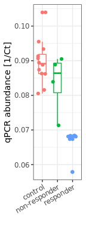

```r
pl <- ggplot(sdata[DaysElapsed == 31], aes(x = Response, y = 1 / Ct,
                                           col = Response)) +
  geom_boxplot(width=0.5) + geom_jitter(width = 0.3) +
  guides(color = "none") + labs(x = "", y = "qPCR abundance [1/Ct]") +
  theme_bw() + theme(axis.text.x = element_text(angle = 30, hjust = 1,
                                                vjust = 1))
fig_data[["Fig. 2C"]] <- sdata[DaysElapsed == 31]
ggsave("figures/qpcr_cycles.svg", width = 1.5, height = 4)
pl
```

And we can see that there is a relationship between qPCR abundance estimates and response.

```r
pairwise.wilcox.test(sdata[, 1/Ct], sdata[, Response],
                     p.adjust.method = "bonferroni")
```

```
cannot compute exact p-value with tiescannot compute exact p-value with tiescannot compute exact p-value with ties
```

```
    Pairwise comparisons using Wilcoxon rank sum test with continuity correction

data:  sdata[, 1/Ct] and sdata[, Response]

              control non-responder
non-responder 0.33    -
responder     1.7e-07 0.41

P value adjustment method: bonferroni
```

We can check how that corresponds to the abundance of Mitochondria and Chloroplasts. For that we will first get the relative abundances of those two in each sample.

```r
chloro_mit <- subset_taxa(ps,
                          Class == "Chloroplast" | Family == "Mitochondria")
rel <- data.table(sample = sample_names(ps),
                  relative = sample_sums(chloro_mit) / sample_sums(ps))
rel <- sdata[rel, on = c(CategoricalID = "sample")]
```

We can visualize this again.

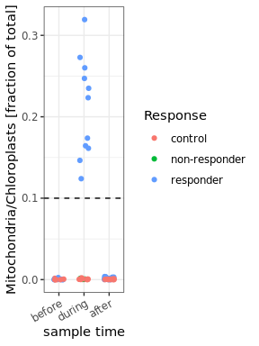

```r
ggplot(rel, aes(x = TimepointCat, y = relative, color = Response)) +
  geom_hline(yintercept = 0.1, lty="dashed") +
  geom_jitter(width=0.2) +
  labs(x="sample time", y="Mitochondria/Chloroplasts [fraction of total]") +
  theme(axis.text.x = element_text(angle = 30, hjust = 1, vjust = 1))
```

```r
fig_data[["Fig. 2B"]] <- rel
ggsave("figures/seaweed_chloro_mit.svg", width=3, height=4)
```

Now we can check how that refers to cycles.

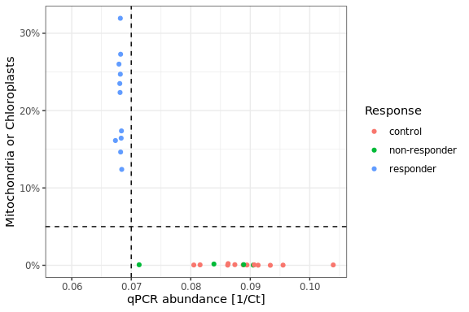

```r
pl <- ggplot(rel[DaysElapsed == 31], aes(x = 1/Ct, y = relative, col = Response)) +
  scale_y_continuous(labels = scales::percent) + geom_point() +
  geom_vline(xintercept = 0.07, lty = "dashed") +
  geom_hline(yintercept = 0.05, lty = "dashed") +
  theme_bw() + labs(x = "qPCR abundance [1/Ct]",
                    y = "Mitochondria or Chloroplasts")
ggsave("figures/qpcr_vs_chloro_mit.svg", height = 4, width = 6)
pl
```

```r
rel[DaysElapsed == 31, cor.test(1/Ct, relative, method="spearman")]
```

```
Cannot compute exact p-value with ties
```

```
    Spearman's rank correlation rho

data:  1/Ct and relative
S = 6047.8, p-value = 2.713e-08
alternative hypothesis: true rho is not equal to 0
sample estimates:
       rho
-0.8461069
```

Or rather do it with discretized cycle times.

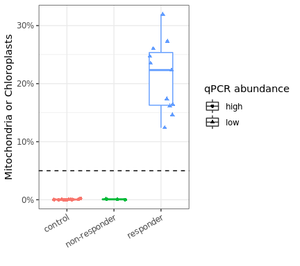

```r
rel[, qpcr_material := c("low", "high")[(1/Ct > 0.07) + 1]]
pl <- ggplot(rel[DaysElapsed == 31], aes(x = Response, y = relative,
                                         col = Response, shape = qpcr_material)) +
  scale_y_continuous(labels = scales::percent) +
  geom_boxplot(position=position_dodge(width=0.6), width=0.5, outlier.color = NA) +
  geom_jitter(width=0.3, aes(group = Response)) +
  geom_hline(yintercept = 0.05, lty = "dashed") +
  theme_bw() + theme(axis.text.x = element_text(angle = 30, hjust = 1,
                                                vjust = 1)) +
  guides(color = "none") + labs(x = "", y = "Mitochondria or Chloroplasts" ,
                                shape = "qPCR abundance")
ggsave("figures/chloro_mit.svg", height = 4, width = 4.5)
pl
```

And there is also a relationship between the fraction of Chloroplasts and Mitochondria and Response:

```r
rel[Days==31, table(Response)]
```

```
Response
      control non-responder     responder
           12             4            12
```

```r
pairwise.wilcox.test(rel[Days==31, relative], rel[Days==31, Response],
                     p.adjust.method = "bonferroni")
```

```
    Pairwise comparisons using Wilcoxon rank sum exact test

data:  rel[Days == 31, relative] and rel[Days == 31, Response]

              control non-responder
non-responder 0.6363  -
responder     4.4e-06 0.0044

P value adjustment method: bonferroni
```

## Weight

```r
weights <- fread("data/weights.csv")
names(weights)[1] <- "Subject"
weights <- melt(weights, id.vars = "Subject",
                variable.name = "date", value.name = "weight")
weights[, date := as.Date(date, "%m/%d/%y")]
weights[, day := date - min(date) + 1]
weights <- weights[sdata[DaysElapsed == 31], on="Subject"]
weights[, weight_delta := weight - weight[day == 0], by="Subject"]
weights[, seaweed := c("no seaweed", "with seaweed")[seaweed + 1]]
weights
```

| Subject | date | weight | day | CategoricalID | Sample | Group | Month | MonthCat | Date | DateCat | DaysElapsed | DaysElapsedCat | Timepoint | TimepointCat | ExperimentPhase | Weight | WeightCat | WeightRounded | WeightRoundedCat | Response | Days | seaweed | Ct | weight_delta |
| --- | --- | --- | --- | --- | --- | --- | --- | --- | --- | --- | --- | --- | --- | --- | --- | --- | --- | --- | --- | --- | --- | --- | --- | --- |
| A1 | 2017-05-10 | 18.5 | 1 days | a1.d31 | sample-3 | A | 6 | 6 | 9 | 9 | 31 | 31 | 3 | during | Antibiotics | 20.0 | 20.0 | 20 | 20 | responder | 31 | no seaweed | 14.85 | NA |
| A1 | 2017-05-14 | 19.0 | 5 days | a1.d31 | sample-3 | A | 6 | 6 | 9 | 9 | 31 | 31 | 3 | during | Antibiotics | 20.0 | 20.0 | 20 | 20 | responder | 31 | no seaweed | 14.85 | NA |
| A1 | 2017-05-19 | 19.3 | 10 days | a1.d31 | sample-3 | A | 6 | 6 | 9 | 9 | 31 | 31 | 3 | during | Antibiotics | 20.0 | 20.0 | 20 | 20 | responder | 31 | no seaweed | 14.85 | NA |
| A1 | 2017-05-24 | 19.7 | 15 days | a1.d31 | sample-3 | A | 6 | 6 | 9 | 9 | 31 | 31 | 3 | during | Antibiotics | 20.0 | 20.0 | 20 | 20 | responder | 31 | no seaweed | 14.85 | NA |
| A1 | 2017-05-29 | 18.8 | 20 days | a1.d31 | sample-3 | A | 6 | 6 | 9 | 9 | 31 | 31 | 3 | during | Antibiotics | 20.0 | 20.0 | 20 | 20 | responder | 31 | no seaweed | 14.85 | NA |
| A1 | 2017-06-03 | 19.0 | 25 days | a1.d31 | sample-3 | A | 6 | 6 | 9 | 9 | 31 | 31 | 3 | during | Antibiotics | 20.0 | 20.0 | 20 | 20 | responder | 31 | no seaweed | 14.85 | NA |
| A1 | 2017-06-05 | 19.3 | 27 days | a1.d31 | sample-3 | A | 6 | 6 | 9 | 9 | 31 | 31 | 3 | during | Antibiotics | 20.0 | 20.0 | 20 | 20 | responder | 31 | no seaweed | 14.85 | NA |
| A1 | 2017-06-07 | 20.6 | 29 days | a1.d31 | sample-3 | A | 6 | 6 | 9 | 9 | 31 | 31 | 3 | during | Antibiotics | 20.0 | 20.0 | 20 | 20 | responder | 31 | no seaweed | 14.85 | NA |
| A1 | 2017-06-09 | 20.0 | 31 days | a1.d31 | sample-3 | A | 6 | 6 | 9 | 9 | 31 | 31 | 3 | during | Antibiotics | 20.0 | 20.0 | 20 | 20 | responder | 31 | no seaweed | 14.85 | NA |
| A1 | 2017-06-10 | 20.0 | 32 days | a1.d31 | sample-3 | A | 6 | 6 | 9 | 9 | 31 | 31 | 3 | during | Antibiotics | 20.0 | 20.0 | 20 | 20 | responder | 31 | no seaweed | 14.85 | NA |

[output cut: 466 more lines]

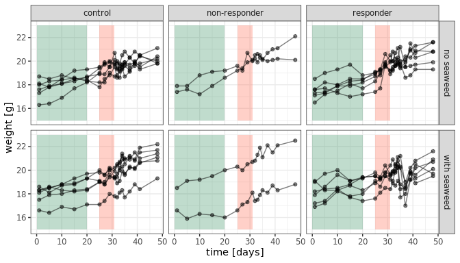

```r
pl <- ggplot(weights, aes(x=day, y=weight)) +
  annotate("rect", xmin = 0, xmax = 20, ymin = 15, ymax = 23,
           fill = "seagreen", alpha = 0.3) +
  annotate("rect", xmin = 25, xmax = 31, ymin = 15, ymax = 23,
           fill = "tomato", alpha = 0.3) +
  geom_point(alpha = 0.5) + geom_line(aes(group = Subject), alpha = 0.5) +
  facet_grid(seaweed ~ Response) + theme_bw() + ylim(15, 23) +
  labs(x = "time [days]", y = "weight [g]") + guides(color = "none")
fig_data[["Fig. 3C"]] <- weights
ggsave("figures/weights_seaweed.svg", width = 7, height = 4)
pl
```

```r
window <- weights[Response == "responder" & day>35 & day<40]
print(nrow(window))
```

```
[1] 24
```

```r
wilcox.test(weight ~ seaweed, data=window)
```

```
cannot compute exact p-value with ties
```

```
    Wilcoxon rank sum test with continuity correction

data:  weight by seaweed
W = 114.5, p-value = 0.01525
alternative hypothesis: true location shift is not equal to 0
```

```r
window <- weights[Response != "non-responder" & day>35 & day<40]
print(nrow(window))
```

```
[1] 48
```

```r
wilcox.test(weight ~ Response, data=weights[Response != "non-responder" & day>35 & day<40])
```

```
cannot compute exact p-value with ties
```

```
    Wilcoxon rank sum test with continuity correction

data:  weight by Response
W = 391, p-value = 0.03438
alternative hypothesis: true location shift is not equal to 0
```

```r
model <- glm(weight ~ day*Response, data=weights)
summary(model)
```

```
Call:
glm(formula = weight ~ day * Response, data = weights)

Deviance Residuals:
     Min        1Q    Median        3Q       Max
-2.83464  -0.47030   0.09121   0.57796   2.04625

Coefficients:
                           Estimate Std. Error t value Pr(>|t|)
(Intercept)               17.501751   0.145650 120.163   <2e-16 ***
day                        0.065502   0.004859  13.481   <2e-16 ***
Responsenon-responder     -0.326615   0.291299  -1.121    0.263
Responseresponder          0.125335   0.205980   0.608    0.543
day:Responsenon-responder  0.013281   0.009718   1.367    0.172
day:Responseresponder     -0.005838   0.006871  -0.850    0.396
---
Signif. codes:  0 ‘***’ 0.001 ‘**’ 0.01 ‘*’ 0.05 ‘.’ 0.1 ‘ ’ 1

(Dispersion parameter for gaussian family taken to be 0.7706972)

    Null deviance: 686.31  on 475  degrees of freedom
Residual deviance: 362.23  on 470  degrees of freedom
AIC: 1234.8

Number of Fisher Scoring iterations: 2
```

```r
model <- lm(weight ~ day*Response, data=weights[Response != "control"])
summary(model)
```

```
Call:
lm(formula = weight ~ day * Response, data = weights[Response !=
    "control"])

Residuals:
    Min      1Q  Median      3Q     Max
-2.8346 -0.5330  0.1137  0.5809  2.0463

Coefficients:
                       Estimate Std. Error t value Pr(>|t|)
(Intercept)           17.175136   0.271420  63.279  < 2e-16 ***
day                    0.078783   0.009054   8.701  3.4e-16 ***
Responseresponder      0.451950   0.313409   1.442   0.1505
day:Responseresponder -0.019119   0.010455  -1.829   0.0686 .
---
Signif. codes:  0 ‘***’ 0.001 ‘**’ 0.01 ‘*’ 0.05 ‘.’ 0.1 ‘ ’ 1

Residual standard error: 0.9445 on 268 degrees of freedom
Multiple R-squared:  0.4349,    Adjusted R-squared:  0.4285
F-statistic: 68.74 on 3 and 268 DF,  p-value: < 2.2e-16
```

## Shannon index

```r
controls <- subset_samples(ps, Response == "control") %>%
            rarefy_even_depth(10000)
```

```
You set `rngseed` to FALSE. Make sure you've set & recorded
 the random seed of your session for reproducibility.
See `?set.seed`

...
3 samples removedbecause they contained fewer reads than `sample.size`.
Up to first five removed samples are:

d1.d1d1.d35d5.d31
...
1237OTUs were removed because they are no longer
present in any sample after random subsampling

...
```

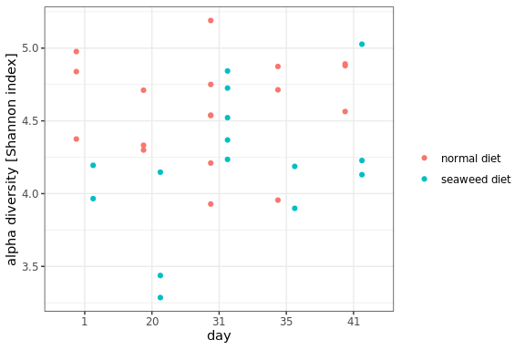

```r
shannon <- estimate_richness(controls, measures = "Shannon")
shannon <- data.table(sample = rownames(shannon), shannon = shannon[, 1])
shannon <- sdata[shannon, on = c(CategoricalID = "sample")]

pl <- ggplot(shannon,
             aes(x = factor(DaysElapsed), y = shannon, color = seaweed,
                 group = interaction(DaysElapsed, seaweed))) +
  geom_jitter(position = position_dodge(width = 0.5)) +
  theme_bw() + scale_color_discrete(labels = c("normal diet", "seaweed diet")) +
  labs(y = "alpha diversity [Shannon index]", x = "day", color = "")
ggsave("figures/shannon_seaweed_time.svg", width = 6, height = 4)
pl
```

Corresponding tests:

```r
shannon[, .(pval = wilcox.test(shannon[seaweed], shannon[!seaweed])$p.value),
        by = "DaysElapsed"]
```

| DaysElapsed | pval |
| --- | --- |
| 1 | 0.2 |
| 20 | 0.1 |
| 31 | 1.0 |
| 35 | 0.4 |
| 41 | 0.7 |

Phyla distributions:

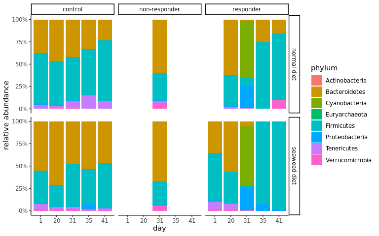

```r
phyla[, relative := reads / sum(reads), by = Sample]
pl <- ggplot(phyla[taxa %in% high_taxa],
             aes(x = factor(DaysElapsed), y = relative, fill = taxa)) +
  geom_bar(stat = "identity", position = "fill") +
  scale_y_continuous(labels = scales::percent) +
  facet_grid(c("normal diet", "seaweed diet")[as.numeric(seaweed) + 1] ~ Response) +
  theme_classic() +
  labs(x = "day", y = "relative abundance", fill = "phylum")
ggsave("figures/phyla_day_seaweed.png", height = 5, width = 8, dpi = 300)
pl
```

Sample sizes:

```r
phyla[, uniqueN(sample), by = c("Response", "seaweed", "DaysElapsed")][order(Response, seaweed)]
```

| Response | seaweed | DaysElapsed | V1 |
| --- | --- | --- | --- |
| control | FALSE | 1 | 3 |
| control | FALSE | 20 | 3 |
| control | FALSE | 31 | 6 |
| control | FALSE | 35 | 3 |
| control | FALSE | 41 | 3 |
| control | TRUE | 1 | 3 |
| control | TRUE | 20 | 3 |
| control | TRUE | 31 | 6 |
| control | TRUE | 35 | 3 |
| control | TRUE | 41 | 3 |

[output cut: 11 more lines]

And the corresponding PERMANOVA:

```r
counts <- as.matrix(taxa_count(controls, NA))
sda <- as(sample_data(controls), "data.frame")
permanova <- adonis(counts ~ seaweed, data = sda)
permanova
```

[output not shown]

And let’s save the raw figure data again.

```r
saveRDS(fig_data, "data/fig_data.rds")
```